# Data Preparation

Anonymous

2025-02-10

This notebook prepares the observational data for its subsequent analysis.

## Indepedent Data

Firstly, load the `csv` sheet containing all observations, which contains both manually and automatically annotated variables.

```r
df.ind <- read.csv('../../data/output/rq4tlr-merged.csv')
```

### Datatype Correction

```r
vars.bool <- c("duplicate", "nameproblem", "scope", "textorder", "iounquantified", "actoractor", "justification", "happy", "meanuc", "lostfr")

to_bool <- function(value) {
  return(value == "True")
}

df.ind <- df.ind %>%
  mutate_at(vars.bool, to_bool)
```

The resulting independent data contains all variables in their correct format.

```r
str(df.ind)
```

```
## 'data.frame':    189 obs. of  30 variables:
##  $ Dataset         : chr  "etour" "etour" "etour" "etour" ...
##  $ File            : chr  "UC1" "UC2" "UC3" "UC4" ...
##  $ duplicate       : logi  FALSE FALSE FALSE FALSE FALSE FALSE ...
##  $ nameproblem     : logi  FALSE FALSE FALSE FALSE FALSE FALSE ...
##  $ scope           : logi  FALSE FALSE FALSE FALSE FALSE FALSE ...
##  $ textorder       : logi  FALSE FALSE FALSE FALSE FALSE FALSE ...
##  $ iounquantified  : logi  FALSE FALSE FALSE FALSE FALSE FALSE ...
##  $ actoractor      : logi  FALSE FALSE FALSE FALSE FALSE FALSE ...
##  $ justification   : logi  FALSE FALSE FALSE FALSE FALSE FALSE ...
##  $ coordambiguity  : num  0 0 0 0 0 0 0 0 0 0 ...
##  $ uidesign        : num  0 0 0 0 0 0 0 0 0 0 ...
##  $ alternative     : num  0 0 0.167 0 0 ...
##  $ inconsistentloa : num  0 0 0 0 0 0 0 0 0 0 ...
##  $ clarification   : num  0 0 0 0 0 0 0 0 0 0 ...
```

[output cut: 16 more lines]

### Value Correction

The values in the `coherence` column contain the value -1.0 whenever the use case subflow contained no more than 1 step. In this case, the coherence value is not meaningful because there cannot be coherence of any sentence to any predecessor.

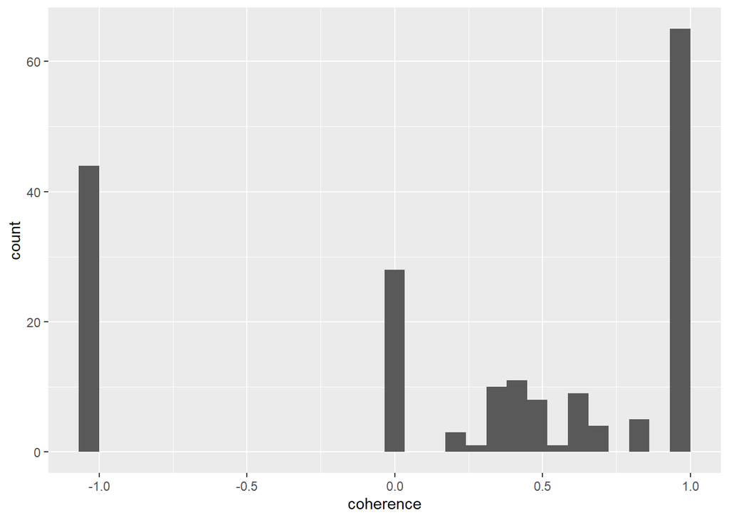

```r
df.ind %>% ggplot(aes(x = coherence)) +
  geom_histogram()
```

The value -1.0 would be misinterpreted by a regression model. Hence, replace it with `NA` to indicate that the value is not applicable.

```r
df.ind <- df.ind %>%
  mutate(coherence = ifelse(coherence == -1.0, NA, coherence))
```

## Dependent Data

The dependent variables are located in the `./data/TLR_results/` directory. The trace link recovery results per data set are stored in separate files.

```r
df.dep.etour <- read.csv('../../data/TLR_results/FTLR/etour_ORG_m59f44_FTLRMcCd_perArtifactMetrics.csv', sep=';') %>%
  mutate(Dataset = 'etour')
df.dep.itrust <- read.csv('../../data/TLR_results/FTLR/itrust_ORG_m59f44_FTLRMcCd_perArtifactMetrics.csv', sep=';') %>%
  mutate(Dataset = 'itrust')

df.dep <- rbind(
  df.dep.itrust,
  df.dep.etour
)
```

The `sourceID` column associates each row of the results with the requirements file that the TLR algorithm attempted to trace. However, the values in this column still contain the `.txt` file extension. To harmonize the file IDs of the dependent and independent data points, remove the file extensions.

```r
df.dep <- df.dep %>%
  rowwise() %>%
  mutate(File = strsplit(sourceID, '\\.')[[1]][1])
```

Then, drop the now unnecessary `sourceID` column.

```r
df.dep <- df.dep %>%
  select(!(sourceID))
```

The resulting data frame contains the following values.

```r
head(df.dep)
```

```
## # A tibble: 6 x 10
## # Rowwise:
##      tp    fp    fn Precision Recall    F1      AP   LAG Dataset File
##   <int> <int> <int>     <dbl>  <dbl> <dbl>   <dbl> <dbl> <chr>   <chr>
## 1     0     7     2     0      0       0   0.0177   114. itrust  UC10E1
## 2     0    15     2     0      0       0   0.0116   140. itrust  UC10E2
## 3     3     5     4     0.375  0.429   0.4 0.456     27  itrust  UC10S1
## 4     0     8     1     0      0       0   0.0435    22  itrust  UC10S2
## 5     0    12     2     0      0       0   0.0121   132  itrust  UC11E1
## 6     0    20     2     0      0       0   0.00912  162  itrust  UC11E2
```

## Finalization

Finally, merge the dependent and independent data frames on the `Dataset` and `File` columns.

```r
df <- merge(df.ind, df.dep, by=c('Dataset', 'File'), all=TRUE)
```

Then, store the file in a location accessible to the data analysis scripts.

```r
write_csv(df, file=file.path('../data/rq4tlr-data.csv'))
```